Guadalupe Torres[^1]

03/30/2025

–> > The purpose of this document is to simulataneously analyze a dataset containing wages of 80 workers a a single manufacturing firm. We have been assigned whether or not age has a quadratic effect on predicted wages. The dataset contains data on the hourly wage, age and education of the employees. The second dataset we will analyze is the Ann Arbor dataset. This dataset conttains data on a portion of the rental market in Ann Arbor, MI. The data includes the monthly rent, number of bedrooms, and the square footage of 40 rental properties.

## 1a. Plotting Wage Against Age

```r
library(readxl)
df <- wages <-read_csv(file = "wages.csv")
head(df)
```

| Wage | Educ | Age |
| --- | --- | --- |
| 17.54 | 12 | 76 |
| 20.93 | 10 | 61 |
| 12.94 | 8 | 75 |
| 19.34 | 6 | 38 |
| 24.12 | 12 | 59 |
| 18.36 | 8 | 51 |

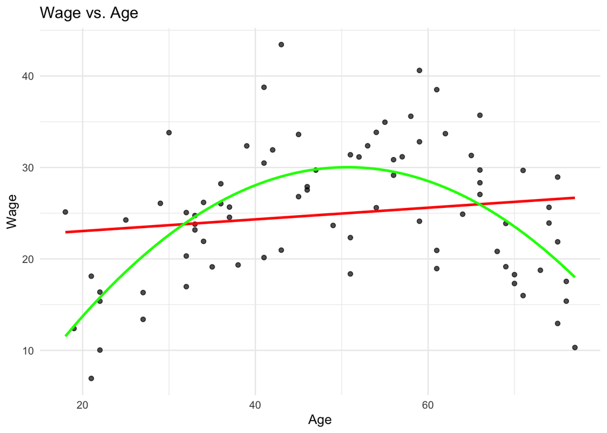

```r
library(readxl)
library(ggplot2)

df <- wages <-read_csv(file = "wages.csv")

ggplot(df, aes(x = Age, y = Wage)) +
  geom_point(alpha = 0.7) +
  geom_smooth(method = "lm", formula = y ~ x, color = "red", se = FALSE) +
  geom_smooth(method = "lm", formula = y ~ poly(x, 2), color = "green", se = FALSE) +
  labs(title = "Wage vs. Age", x = "Age", y = "Wage") +
  theme_minimal()
```

```r
linear_model <-lm(Wage ~ Educ +Age, data = wages)
summary(linear_model)
```

```
##
## Call:
## lm(formula = Wage ~ Educ + Age, data = wages)
##
## Residuals:
##      Min       1Q   Median       3Q      Max
## -13.2598  -1.9734   0.3785   2.7700   9.9533
##
## Coefficients:
##             Estimate Std. Error t value Pr(>|t|)
## (Intercept)  2.63808    2.36649   1.115    0.268
## Educ         1.44101    0.13123  10.981   <2e-16 ***
## Age          0.04717    0.03062   1.541    0.127
## ---
## Signif. codes:  0 '***' 0.001 '**' 0.01 '*' 0.05 '.' 0.1 ' ' 1
##
## Residual standard error: 4.678 on 77 degrees of freedom
## Multiple R-squared:  0.6187, Adjusted R-squared:  0.6088
## F-statistic: 62.47 on 2 and 77 DF,  p-value: < 2.2e-16
```

```r
poly_model <- lm(mpg ~ poly(wt, 2) + poly(hp,2) + am, data = mtcars)
summary(poly_model)
```

```
##
## Call:
## lm(formula = mpg ~ poly(wt, 2) + poly(hp, 2) + am, data = mtcars)
##
## Residuals:
##     Min      1Q  Median      3Q     Max
## -3.0533 -1.7553 -0.3802  1.2768  4.6422
##
## Coefficients:
##              Estimate Std. Error t value Pr(>|t|)
## (Intercept)   20.2026     0.6772  29.833  < 2e-16 ***
## poly(wt, 2)1 -19.1445     4.8432  -3.953 0.000529 ***
## poly(wt, 2)2   6.5001     2.5348   2.564 0.016464 *
## poly(hp, 2)1 -12.7493     3.5183  -3.624 0.001237 **
## poly(hp, 2)2   5.5494     2.6177   2.120 0.043716 *
## am            -0.2756     1.3726  -0.201 0.842446
## ---
## Signif. codes:  0 '***' 0.001 '**' 0.01 '*' 0.05 '.' 0.1 ' ' 1
##
## Residual standard error: 2.174 on 26 degrees of freedom
## Multiple R-squared:  0.8909, Adjusted R-squared:  0.8699
## F-statistic: 42.46 on 5 and 26 DF,  p-value: 1.07e-11
```

## 1b:Estimating a multiple regression model of Wage using Age & Education

```r
library(readxl)

df <- wages <-read_csv(file = "wages.csv")

model <- lm(Wage ~ Age + Educ, data = df)

summary(model)
```

```
##
## Call:
## lm(formula = Wage ~ Age + Educ, data = df)
##
## Residuals:
##      Min       1Q   Median       3Q      Max
## -13.2598  -1.9734   0.3785   2.7700   9.9533
##
## Coefficients:
##             Estimate Std. Error t value Pr(>|t|)
## (Intercept)  2.63808    2.36649   1.115    0.268
## Age          0.04717    0.03062   1.541    0.127
## Educ         1.44101    0.13123  10.981   <2e-16 ***
## ---
## Signif. codes:  0 '***' 0.001 '**' 0.01 '*' 0.05 '.' 0.1 ' ' 1
##
## Residual standard error: 4.678 on 77 degrees of freedom
## Multiple R-squared:  0.6187, Adjusted R-squared:  0.6088
## F-statistic: 62.47 on 2 and 77 DF,  p-value: < 2.2e-16
```

–> Based on the results, we can conclude that the education variable is the most significant. For each additional year of education, hourly wages increases by $1.44. We can also draw a conclusion that age is not a signifact variable in determining wages. We can assume that a simple linear effectt of age on wage is not the best model in this case.

## 1c:Estimating another multple regression model of Wage using Age/Education

```r
library(readxl)
library(ggplot2)

df <- wages <-read_csv(file = "wages.csv")
linear_model <- lm(Wage ~ Age + Educ, data = df)

quadratic_model <- lm(Wage ~ Age + I(Age^2) + Educ, data = df)

summary(linear_model)
```

```
##
## Call:
## lm(formula = Wage ~ Age + Educ, data = df)
##
## Residuals:
##      Min       1Q   Median       3Q      Max
## -13.2598  -1.9734   0.3785   2.7700   9.9533
##
## Coefficients:
##             Estimate Std. Error t value Pr(>|t|)
## (Intercept)  2.63808    2.36649   1.115    0.268
## Age          0.04717    0.03062   1.541    0.127
## Educ         1.44101    0.13123  10.981   <2e-16 ***
## ---
## Signif. codes:  0 '***' 0.001 '**' 0.01 '*' 0.05 '.' 0.1 ' ' 1
##
## Residual standard error: 4.678 on 77 degrees of freedom
## Multiple R-squared:  0.6187, Adjusted R-squared:  0.6088
## F-statistic: 62.47 on 2 and 77 DF,  p-value: < 2.2e-16
```

```r
summary(quadratic_model)
```

```
##
## Call:
## lm(formula = Wage ~ Age + I(Age^2) + Educ, data = df)
##
## Residuals:
##     Min      1Q  Median      3Q     Max
## -8.7285 -1.7124 -0.3596  1.9203  7.8048
##
## Coefficients:
##               Estimate Std. Error t value Pr(>|t|)
## (Intercept) -22.721936   3.022859  -7.517 9.22e-11 ***
## Age           1.350002   0.133973  10.077 1.19e-15 ***
## I(Age^2)     -0.013322   0.001354  -9.840 3.34e-15 ***
## Educ          1.253959   0.089631  13.990  < 2e-16 ***
## ---
## Signif. codes:  0 '***' 0.001 '**' 0.01 '*' 0.05 '.' 0.1 ' ' 1
##
## Residual standard error: 3.123 on 76 degrees of freedom
## Multiple R-squared:  0.8323, Adjusted R-squared:  0.8257
## F-statistic: 125.7 on 3 and 76 DF,  p-value: < 2.2e-16
```

```r
cat("Linear Model R-squared:", summary(linear_model)$r.squared, "\n")
```

```
## Linear Model R-squared: 0.6186944
```

```r
cat("Quadratic Model R-squared:", summary(quadratic_model)$r.squared, "\n")
```

```
## Quadratic Model R-squared: 0.8323164
```

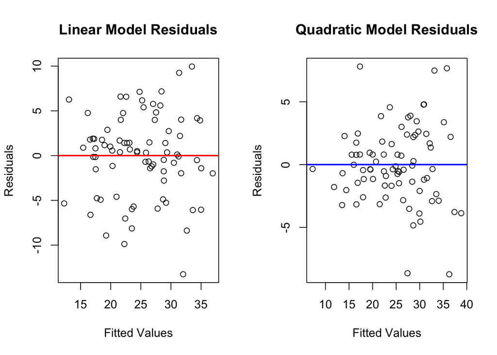

```r
par(mfrow=c(1,2))  # Split plot window into 2

plot(linear_model$fitted.values, residuals(linear_model),
     main="Linear Model Residuals", xlab="Fitted Values", ylab="Residuals")
abline(h=0, col="red", lwd=2)

plot(quadratic_model$fitted.values, residuals(quadratic_model),
     main="Quadratic Model Residuals", xlab="Fitted Values", ylab="Residuals")
abline(h=0, col="blue", lwd=2)
```

–> The results show that by fitting age using a quadratic relationship, we receive better results. The r-square for the quadratic model is more significant then the linear model we fit in part a.